# Algae albedo model

```r
library(tidyverse)
library(here)
library(broom)
library(janitor)
library(readxl)
library(ggpubr)
library(cowplot)
```

```r
# field radiometer data convolved to albedo
albedo <- read_csv(here("data/radiometer/as_bb_albedo.csv"), col_types = cols())
v_albedo <- read_csv(here("data/radiometer/as_viz_albedo.csv"), col_types = cols()) # visible albedo
nir_albedo <- read_csv(here("data/radiometer/as_nir_albedo.csv"), col_types = cols()) # NIR albedo

color <- read_csv(here("data/field_sample_meta/final_sample_list.csv"))
# algae abundance (data processed in algae abundance regression)
cc <- read_csv(here("data/cellcount/cell_long.csv"), col_types = cols())

# RGND
rgnd <- read_csv(here("data/radiometer/as_s2_indices.csv"), col_types = cols())

# IRF
scans <- read_csv(here("data/radiometer/sample_scans.csv"), col_types = cols())
solar_rad <- read_excel(here("data/PVL_SpectrumCalculator_Whistler_2021-07-31_13:00:00.xlsx"), sheet = 3)
```

remove padding zero and “21” from sample ID

```r
shorten_uid <- function(str){
  site = str %>% str_sub(1,3)
  num = str %>% str_remove("21.") %>% parse_number()
  paste0(site, num)
}

shorten_uid_wrap <- function(df){
  df %>% mutate(sample_id = shorten_uid(sample_id), .keep = "unused")
}
```

# Compare duplicate albedo scans

QC

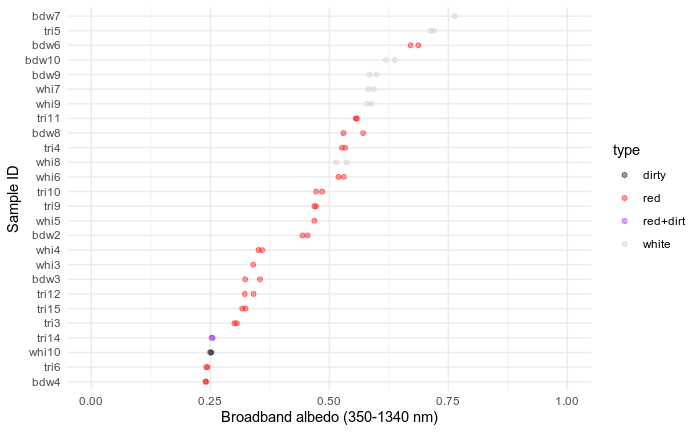

```r
albedo %>%
  shorten_uid_wrap() %>%
  left_join(color) %>%
  ggplot(aes(x=  sample_id %>% fct_reorder(albedo), y = albedo, color = type)) +
  geom_point(alpha = 0.4) +
  labs(x = "Sample ID", y = "Broadband albedo (350-1340 nm)") +
  ylim(0,1) +
  coord_flip() +
  theme_minimal() +
  scale_color_manual(values =c("black","red","purple", "grey80"))
```

Seems reasonable. Use the mean value for the rest of this analysis

# Take mean values of everything

```r
albedo_wide <- albedo %>%
  group_by(sample_id) %>%
  summarise(mean_albedo = mean(albedo), sd_albedo = sd(albedo))
albedo_wide
```

| sample_id | mean_albedo | sd_albedo |
| --- | --- | --- |
| bdw21.02 | 0.4490087 | 0.007870369 |
| bdw21.03 | 0.3386520 | 0.022028463 |
| bdw21.04 | 0.2404472 | 0.001036953 |
| bdw21.06 | 0.6787717 | 0.011069637 |
| bdw21.07 | 0.7631822 | NA |
| bdw21.08 | 0.5503914 | 0.029252179 |
| bdw21.09 | 0.5920192 | 0.010389990 |
| bdw21.10 | 0.6280855 | 0.013351031 |
| tri21.03 | 0.3032390 | 0.003662065 |
| tri21.04 | 0.5297748 | 0.004796602 |

[output cut: 16 more lines]

```r
v_albedo_wide <- v_albedo %>%
  group_by(sample_id) %>%
  summarise(mean_vis_albedo = mean(albedo), sd_vis_albedo = sd(albedo))
v_albedo_wide
```

| sample_id | mean_vis_albedo | sd_vis_albedo |
| --- | --- | --- |
| bdw21.02 | 0.4799043 | 0.009234185 |
| bdw21.03 | 0.3237538 | 0.024973423 |
| bdw21.04 | 0.1973852 | 0.002642989 |
| bdw21.06 | 0.8148450 | 0.011941077 |
| bdw21.07 | 0.9838385 | NA |
| bdw21.08 | 0.6755640 | 0.037149471 |
| bdw21.09 | 0.7530310 | 0.012926279 |
| bdw21.10 | 0.8085662 | 0.017279716 |
| tri21.03 | 0.2560705 | 0.006663767 |
| tri21.04 | 0.6310541 | 0.006139292 |

[output cut: 16 more lines]

```r
nir_albedo_wide <- nir_albedo %>%
  group_by(sample_id) %>%
  summarise(mean_nir_albedo = mean(albedo), sd_nir_albedo = sd(albedo))

all_albedo <- left_join(albedo_wide, v_albedo_wide, by = "sample_id") %>%
  left_join(nir_albedo_wide, by = "sample_id")
all_albedo
```

| sample_id | mean_albedo | sd_albedo | mean_vis_albedo | sd_vis_albedo | mean_nir_albedo | sd_nir_albedo |
| --- | --- | --- | --- | --- | --- | --- |
| bdw21.02 | 0.4490087 | 0.007870369 | 0.4799043 | 0.009234185 | 0.5134975 | 0.0080933653 |
| bdw21.03 | 0.3386520 | 0.022028463 | 0.3237538 | 0.024973423 | 0.4360499 | 0.0235982421 |
| bdw21.04 | 0.2404472 | 0.001036953 | 0.1973852 | 0.002642989 | 0.3488619 | 0.0005870682 |
| bdw21.06 | 0.6787717 | 0.011069637 | 0.8148450 | 0.011941077 | 0.6649322 | 0.0125466975 |
| bdw21.07 | 0.7631822 | NA | 0.9838385 | NA | 0.6461255 | NA |
| bdw21.08 | 0.5503914 | 0.029252179 | 0.6755640 | 0.037149471 | 0.5130423 | 0.0254879284 |
| bdw21.09 | 0.5920192 | 0.010389990 | 0.7530310 | 0.012926279 | 0.5152985 | 0.0097085392 |
| bdw21.10 | 0.6280855 | 0.013351031 | 0.8085662 | 0.017279716 | 0.5352724 | 0.0115223941 |
| tri21.03 | 0.3032390 | 0.003662065 | 0.2560705 | 0.006663767 | 0.4387739 | 0.0011458805 |
| tri21.04 | 0.5297748 | 0.004796602 | 0.6310541 | 0.006139292 | 0.5374608 | 0.0043432078 |

[output cut: 16 more lines]

Make wide versions of cell count and RGND data

```r
cc_wide <- cc %>%
  pivot_wider(names_from= name, values_from = c("mean", "sd"))

rgnd_wide <- rgnd %>%
  filter(name=="rgnd") %>%
  select(-name) %>%
  rename(mean_rgnd = mean, sd_rgnd = sd)
```

Combine all data into a single data frame

```r
# df containing all data used in this analysis
dat <- all_albedo %>%
  left_join(cc_wide) %>%
  left_join(rgnd_wide) %>%
  # shorten the sample ID for plotting
  mutate(sample_id = sample_id %>% str_remove("21.0"),# Remove the 21. from the sample IDs
         sample_id = sample_id %>% str_remove("21.")) %>%
  left_join(color)
```

# Compute IRF

For comparison with other studies (e.g Khan, Ganey)

Approach: multiply incoming solar radiation by delta albedo (mean white snow albedo)

Tidy the incident solar data

```r
srad <- solar_rad %>%
  janitor::clean_names() %>%
  select(wavelength_nm, global_into_module_w_m2_nm) %>%
  rename(wvl = wavelength_nm)

scan2 <- scans %>% # SLOW!!!!!! ~30 seconds on my laptop
    # shorten the sample ID for plotting
  mutate(sample_id = sample_id %>% str_remove("21.0"),# Remove the 21. from the sample IDs
         sample_id = sample_id %>% str_remove("21.")) %>%
  group_by(sample_id, wvl) %>%
  summarise(mean = mean(tgt_ref_ratio),
            sd = sd(tgt_ref_ratio)) %>%
  ungroup()
```

[output not shown]

get white snow mean albedo, to use as a baseline

```r
white_samples <- dat %>%
  filter(type=="white") %>%
  pull(sample_id)

white_snow_means <- scan2 %>%
  filter(sample_id %in% white_samples) %>%
  group_by(wvl) %>%
  summarise(white_mean = mean(mean))
```

compute how much the dirty and red snow reduce the albedo relative to white snow “delta albedo”

```r
irfs <- scan2 %>%
  # filter to get only the red and dirty samples
  filter(!(sample_id %in% white_samples)) %>%
  left_join(white_snow_means, by ="wvl") %>%
  # compute delta albedo = reduction in albedo relative to white snow
  mutate(delta_albedo = white_mean - mean) %>%
  inner_join(srad) %>% # incoming, downwelling radiation (use inner join because 10 nm bins)
  # IRF = change in albedo due to algae * downwelling radiation
  # following Ganey 2017, multiply by 10 to account for the 10 nm increments
  mutate(irf = 10 * delta_albedo * global_into_module_w_m2_nm,
         irf_sd = 10* sd * global_into_module_w_m2_nm)
irf_full <- irfs %>%
  # get the total IRF for each sample (sum across wavelengths)
  group_by(sample_id) %>%
  summarise(irf = sum(irf), irf_sd = sum(irf_sd)) %>%
  left_join(dat) %>% # cell abundance metrics
  ungroup()
irf_full
```

| sample_id | irf | irf_sd | mean_albedo | sd_albedo | mean_vis_albedo | sd_vis_albedo | mean_nir_albedo | sd_nir_albedo | mean_bil_cells_per_sq_m | mean_cell_area_percent | mean_cell_cm2_per_l | sd_bil_cells_per_sq_m | sd_cell_area_percent | sd_cell_cm2_per_l | mean_rgnd | sd_rgnd | type |
| --- | --- | --- | --- | --- | --- | --- | --- | --- | --- | --- | --- | --- | --- | --- | --- | --- | --- |
| bdw2 | 148.598357 | 6.6253562 | 0.4490087 | 0.007870369 | 0.4799043 | 0.009234185 | 0.5134975 | 0.0080933653 | 0.95492966 | 21.237238 | 133.43750 | 0.33761862 | 0.5486303 | 3.447146 | 0.21374803 | 0.0007259154 | red |
| bdw3 | 239.184042 | 18.1476740 | 0.3386520 | 0.022028463 | 0.3237538 | 0.024973423 | 0.4360499 | 0.0235982421 | 1.00585924 | 47.956567 | 470.81250 | 0.05401898 | 0.5671993 | 5.568466 | 0.31675465 | 0.0062983388 | red |
| bdw4 | 319.666743 | 1.5219861 | 0.2404472 | 0.001036953 | 0.1973852 | 0.002642989 | 0.3488619 | 0.0005870682 | 3.30071436 | 139.599496 | 1178.93750 | 0.31398532 | 1.7059869 | 14.407301 | 0.36811391 | 0.0078074010 | red |
| bdw6 | -39.544040 | 9.2389838 | 0.6787717 | 0.011069637 | 0.8148450 | 0.011941077 | 0.6649322 | 0.0125466975 | NA | NA | NA | NA | NA | NA | 0.08321489 | 0.0022785519 | red |
| bdw8 | 68.779859 | 23.8908336 | 0.5503914 | 0.029252179 | 0.6755640 | 0.037149471 | 0.5130423 | 0.0254879284 | 0.08482958 | 6.202348 | 59.40625 | 0.09380786 | 7.5226676 | 72.052308 | 0.03307749 | 0.0016078693 | red |
| tri10 | 119.186047 | 7.4871810 | 0.4785074 | 0.008909885 | 0.6105252 | 0.012913109 | 0.4373336 | 0.0062789123 | 0.05920564 | 5.039880 | 42.56250 | 0.04186471 | 3.6108311 | 30.493980 | 0.02517663 | 0.0027315251 | red |
| tri11 | 54.588820 | 1.4836787 | 0.5568434 | 0.001542960 | 0.6925237 | 0.001447116 | 0.5306630 | 0.0019480607 | 0.06604930 | 2.737744 | 25.90625 | 0.05499703 | 3.0034814 | 28.420828 | 0.04494470 | 0.0003366743 | red |
| tri12 | 242.325572 | 11.0761572 | 0.3315727 | 0.013146777 | 0.3780874 | 0.017151746 | 0.3556802 | 0.0116397610 | 0.37823172 | 16.769560 | 135.78125 | 0.10508449 | 5.6996287 | 46.149257 | 0.12933831 | 0.0075515654 | red |
| tri13 | 211.852088 | 38.8803981 | NA | NA | NA | NA | NA | NA | NA | NA | NA | NA | NA | NA | NA | NA | NA |
| tri14 | 307.194410 | 2.0375878 | 0.2538459 | 0.001585949 | 0.2826688 | 0.003842234 | 0.2801922 | 0.0006162188 | 0.49377821 | 21.864905 | 202.03125 | 0.17306896 | 6.2753639 | 57.984227 | 0.14738660 | 0.0054910559 | red+dirt |

[output cut: 12 more lines]

# plot

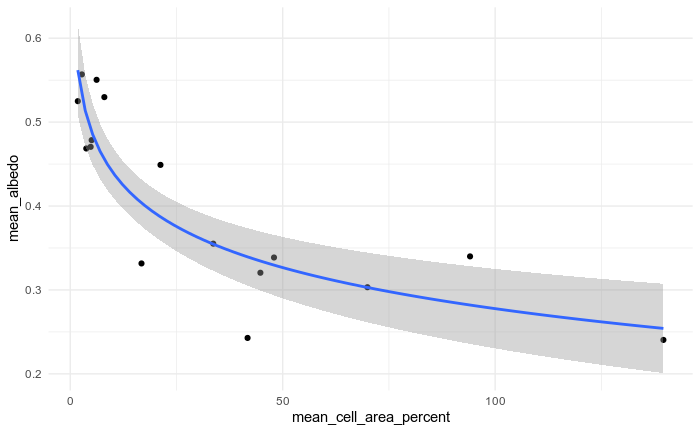

## plot template function

```r
theme_set(theme_minimal())


my_plot <- function(dat, x, y, xsd, ysd, formula){
  dat %>%
    filter(type %in% c("white", "red")) %>%
    drop_na({{x}},{{y}},{{xsd}},{{ysd}}) %>% # geom_smooth dosent accept NA
    ggplot(aes(y = {{y}}, x = {{x}})) +
    geom_smooth(method = "lm", se = FALSE, color = "#F8766D", formula = formula, data = dat %>% filter(type=="red")) +
    geom_point(aes(fill = type), color="black", pch = 21, size = 2.4) +
    # the Y axis SD crossbar
    geom_linerange(aes(ymin = {{y}} - {{ysd}},
                        ymax = {{y}} + {{ysd}}),
                        alpha = 0.4) +
    # the X axis crossbar
    geom_linerange(aes(xmin = {{x}} - {{xsd}},
                     xmax = {{x}} + {{xsd}}),
                  alpha = 0.4)
}
```

## A. albedo vs algae abund

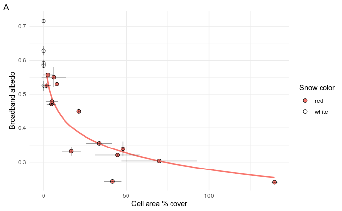

```r
pa <- my_plot(dat,
              x = mean_cell_area_percent,
              y = mean_albedo,
              xsd = sd_cell_area_percent,
              ysd = sd_albedo,
              formula = y~log(x)) +
  labs(x = "Cell area % cover", y = "Broadband albedo", fill = "Snow color", tag = "A") +
  scale_fill_manual(values = c("#F8766D", "white"))
pa
```

## B albedo vs RGND

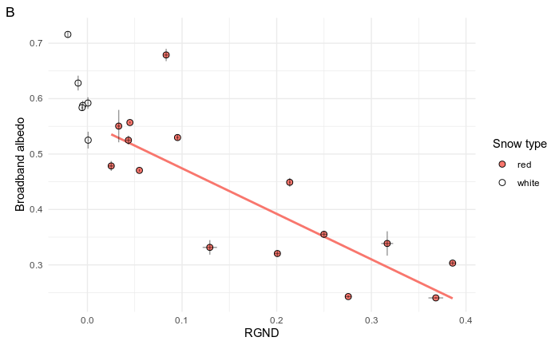

## C. algae abund vs IRF

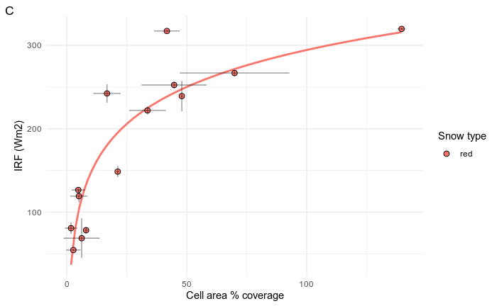

```r
pc <- irf_full %>%
  drop_na(type) %>%
  my_plot(x = mean_cell_area_percent, y = irf, xsd = sd_cell_area_percent, ysd = irf_sd, formula = y~0+ log(x)) +
  labs(y = "IRF (Wm2)", x = "Cell area % coverage", fill = "Snow type", tag = "C") +
  scale_fill_manual(values = c("#F8766D"))
pc
```

## Combine panels (Fig 3)

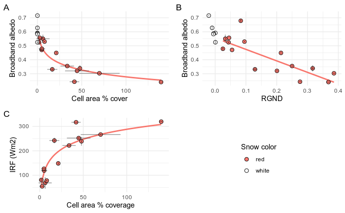

for some reason using ggsave offsets the std error bars. save using Plots GUI

# Regression coefficients

```r
# don't include white, dirty snow in models
mod_dat <- dat %>%
  filter(type == "red")
```

## A. albedo vs algae area

```r
albedo_algae_mod <- lm(mean_albedo ~ log(mean_cell_area_percent), data = mod_dat)
tidy(albedo_algae_mod)
```

| term | estimate | std.error | statistic | p.value |
| --- | --- | --- | --- | --- |
| (Intercept) | 0.60277173 | 0.030231956 | 19.938231 | 1.121385e-11 |
| log(mean_cell_area_percent) | -0.07058527 | 0.009810106 | -7.195158 | 4.599404e-06 |

albedo = (0.6 +/- 0.03) - 0.07 +/- 0.01 * log(Cell Area Percent Cover)

```r
summary(albedo_algae_mod)$r.squared # .80
```

```
[1] 0.787138
```

##B. albedo vs RGND

```r
albedo_rgnd_mod <- lm(mean_albedo ~ mean_rgnd, data = mod_dat)
tidy(albedo_rgnd_mod)
```

| term | estimate | std.error | statistic | p.value |
| --- | --- | --- | --- | --- |
| (Intercept) | 0.5562211 | 0.03218456 | 17.282237 | 2.588839e-11 |
| mean_rgnd | -0.8207256 | 0.16024392 | -5.121727 | 1.252066e-04 |

albedo = 0.55 - 0.82 +/- 0.16 RGND delta_albedo = - 0.82 +/- 0.16 RGND

(t(17) =-5.1, p<0.001)

```r
albedo_rgnd_mod %>%
  tidy() %>%
  write_csv(here("data/albedo_coefs.csv"))
```

```r
summary(albedo_rgnd_mod)$r.squared # 0.65
```

```
[1] 0.6362056
```

## C. IRF vs algae area

```r
irf_mod <- lm(irf ~ 0 + log(mean_cell_area_percent), data = irf_full %>% filter(type == "red"))
irf_mod %>% tidy()
```

| term | estimate | std.error | statistic | p.value |
| --- | --- | --- | --- | --- |
| log(mean_cell_area_percent) | 63.92734 | 3.351864 | 19.07218 | 6.27258e-12 |

IRF = 64 +/- 3.5 log(frac_red_percent)

```r
summary(irf_mod)$r.squared
```

```
[1] 0.9603958
```

sanity check

```r
log(100)*59
```

```
[1] 271.705
```

# compare IRF with Ganey, Khan

compute a 350-850 nm IRF for direct comparison with Ganey, Khan

```r
irf2 <- irfs %>%
  filter(wvl>=350, wvl<=850) %>%
  group_by(sample_id) %>%
  summarise(irf = sum(irf),
            irf_sd = sum(irf_sd)) %>%
  left_join(dat) %>%  # cell abundance metrics
  ungroup()
```

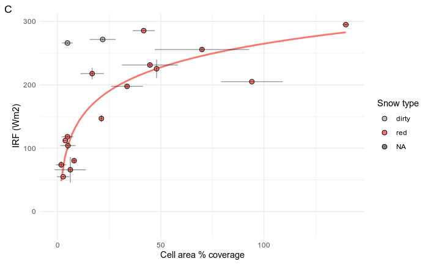

```r
my_plot(irf2, x = mean_cell_area_percent, y = irf, xsd = sd_cell_area_percent, ysd = irf_sd, formula = y~log(x)) +
  labs(y = "IRF (Wm2)", x = "Cell area % coverage", fill = "Snow type", tag = "C") +
  scale_fill_manual(values = c("gray", "#F8766D"))
```

Very similar to our full albedo IRF (the NIR does not contribute much)

# Categorical comparison red, white, dirty snow

## mean values for BB, visible, NIR albedo

```r
dat %>%
  select(type, contains("mean")) %>%
  group_by(type) %>%
  summarise_all(mean)
```

| type | mean_albedo | mean_vis_albedo | mean_nir_albedo | mean_bil_cells_per_sq_m | mean_cell_area_percent | mean_cell_cm2_per_l | mean_rgnd |
| --- | --- | --- | --- | --- | --- | --- | --- |
| dirty | 0.2509051 | 0.3115887 | 0.2430084 | 0.1209578 | 4.808071 | 39.7500 | 0.01285990 |
| red | 0.4223318 | 0.4846769 | 0.4491815 | NA | NA | NA | 0.16313534 |
| red+dirt | 0.2538459 | 0.2826688 | 0.2801922 | 0.4937782 | 21.864905 | 202.0312 | 0.14738660 |
| white | 0.6279405 | 0.8140774 | 0.5454822 | 0.0000000 | 0.000000 | 0.0000 | -0.00665425 |

```r
dat %>%
  group_by(type) %>%
  summarise(min = min(mean_vis_albedo))
```

| type | min |
| --- | --- |
| dirty | 0.3115887 |
| red | 0.1973852 |
| red+dirt | 0.2826688 |
| white | 0.6705908 |

## plot

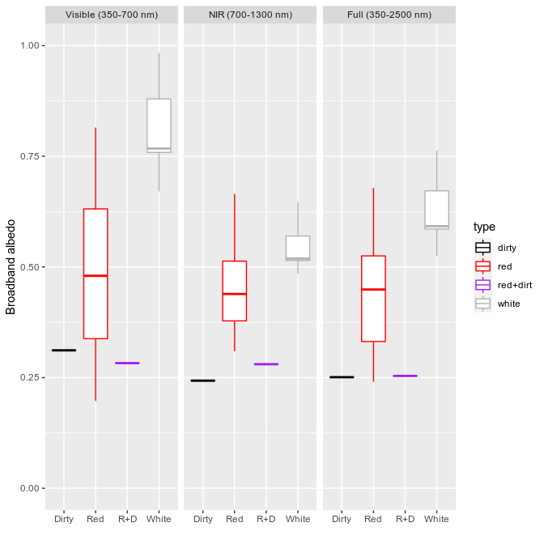

```r
# ggsave(here("figs/bb_albedo_boxplot.png"), height = 8, width = 5)
```

## NIR albedo white vs red ANOVA

```r
# anova
nir_mod <- lm(mean_nir_albedo~type, data = dat %>% filter(type!="dirty"))
summary(nir_mod)
```

```
Call:
lm(formula = mean_nir_albedo ~ type, data = dat %>% filter(type !=
    "dirty"))

Residuals:
     Min       1Q   Median       3Q      Max
-0.13951 -0.05047 -0.01113  0.05996  0.21575

Coefficients:
            Estimate Std. Error t value Pr(>|t|)
(Intercept)  0.44918    0.01963   22.89   <2e-16 ***
typewhite    0.09630    0.03634    2.65   0.0146 *
---
Signif. codes:  0 ‘***’ 0.001 ‘**’ 0.01 ‘*’ 0.05 ‘.’ 0.1 ‘ ’ 1

Residual standard error: 0.08092 on 22 degrees of freedom
Multiple R-squared:  0.242, Adjusted R-squared:  0.2075
F-statistic: 7.022 on 1 and 22 DF,  p-value: 0.01463
```

p=0.0146 red different from white in the NIR albedo